# EDA- Exploratory Data Analysis

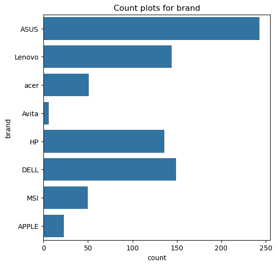

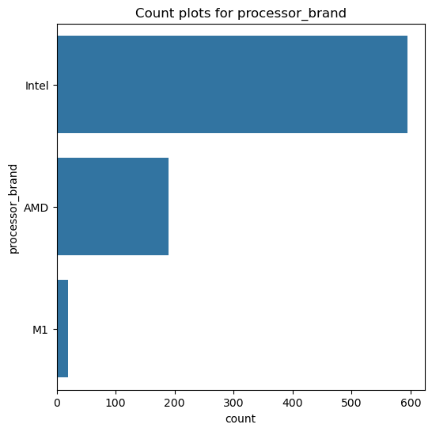

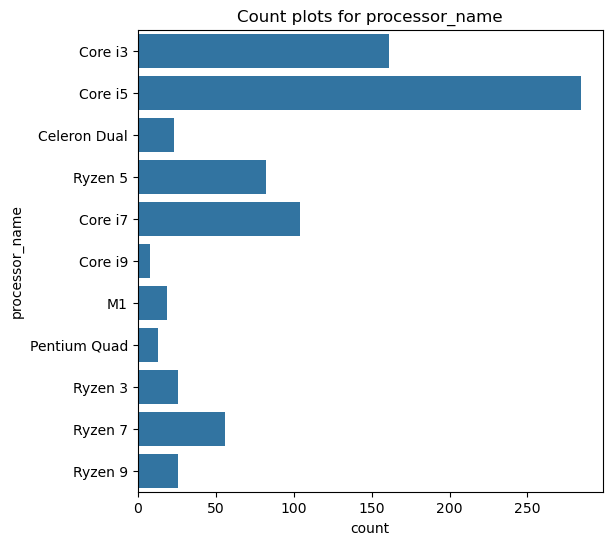

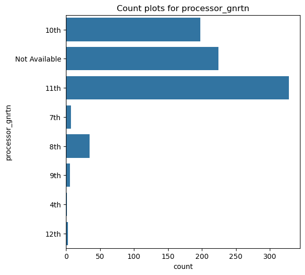

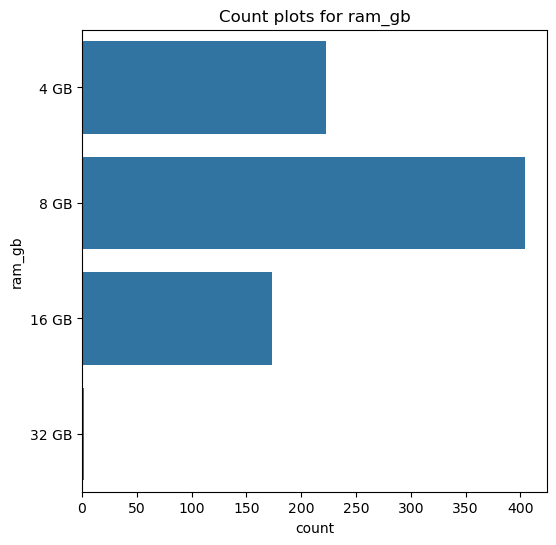

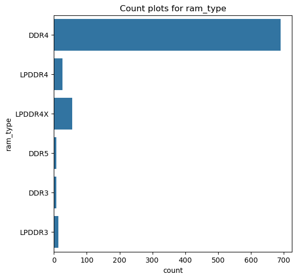

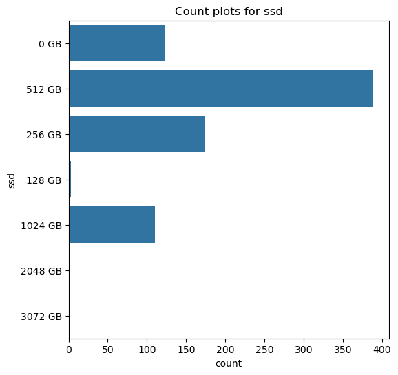

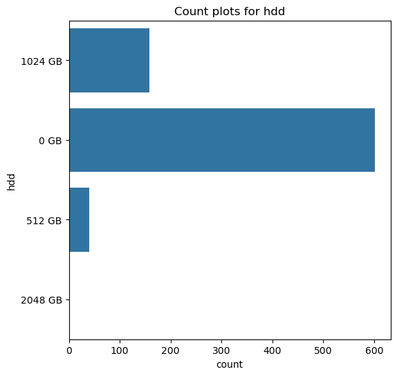

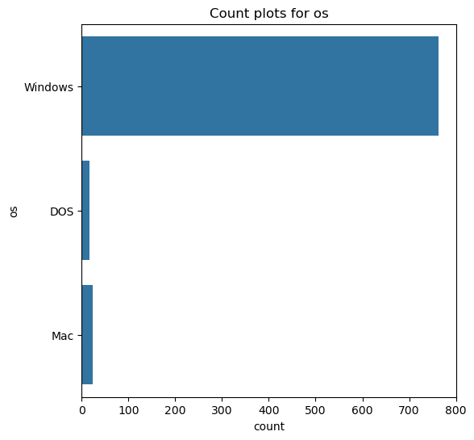

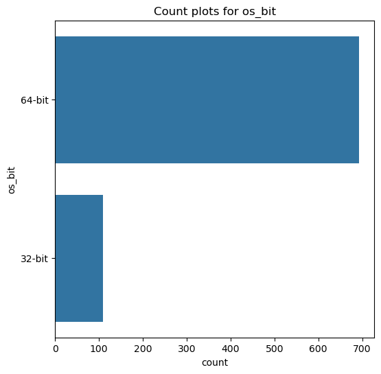

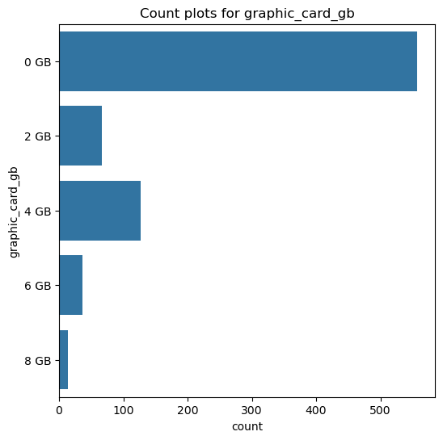

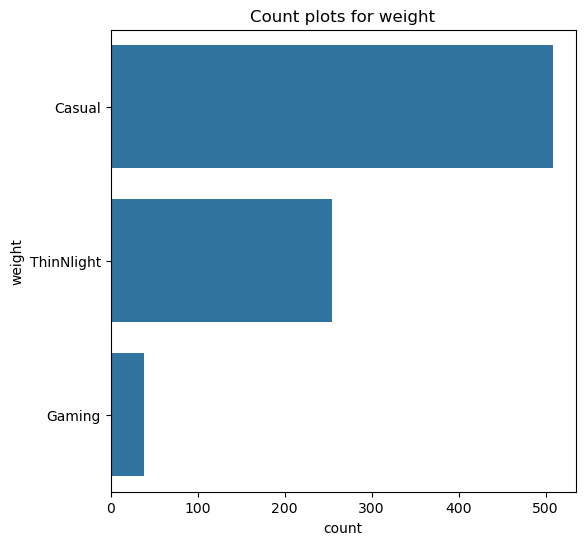

[4 more figures not shown]

```python
for i in cat:
    plt.figure(figsize=(6,6))
    sns.countplot(df_cleaned[i])
    plt.title(f"Count plots for {i}")
    plt.show()
```

Mac and DOS are provided in less than 5% of laptops

Only 10% of laptops are providing 32-bit OS

check for the ratings : 8GB- rating 4gb-rating

quantity => 8gb vs qty 4gb vs qty

os-bit: most of the laptops are providing 64 bit very few provide 32 bit

user demand?

```python
print(cat)
```

```
['brand', 'processor_brand', 'processor_name', 'processor_gnrtn', 'ram_gb', 'ram_type', 'ssd', 'hdd', 'os', 'os_bit', 'graphic_card_gb', 'weight', 'warranty', 'Touchscreen', 'msoffice', 'rating']
```

```python
df['brand'].unique()
```

```
array(['ASUS', 'Lenovo', 'acer', 'Avita', 'HP', 'DELL', 'MSI', 'APPLE'],
      dtype=object)
```

```python
df['brand'].value_counts()
```

```
brand
ASUS      243
DELL      149
Lenovo    144
HP        136
acer       51
MSI        50
APPLE      23
Avita       6
Name: count, dtype: int64
```

### Use any one method to plot bar graphs or histograms

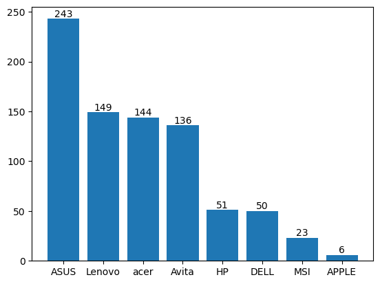

```python
bars = plt.bar(df['brand'].unique(),df['brand'].value_counts())
plt.bar_label(bars)
plt.show()
```

Classic single-letter codes:

'b' = blue

'g' = green

'r' = red

'c' = cyan

'm' = magenta

'y' = yellow

'k' = black

```
<BarContainer object of 8 artists>
```

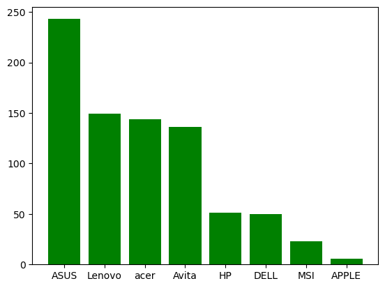

```python
plt.bar(df['brand'].unique(),df['brand'].value_counts(),color='g')
```

```
<BarContainer object of 8 artists>
```

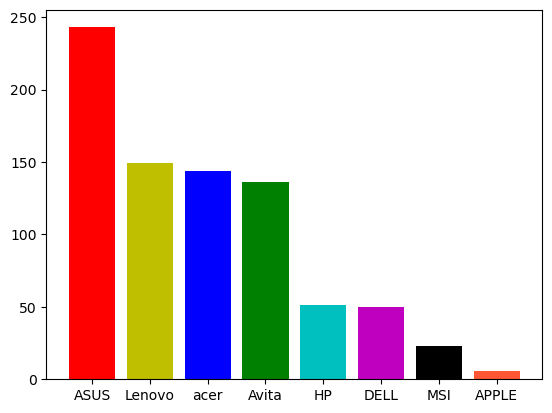

```python
c= ['r','y','b','g','c','m','k','#FF5733']
plt.bar(df['brand'].unique(),df['brand'].value_counts(),color=c)
```

```
<BarContainer object of 8 artists>
```

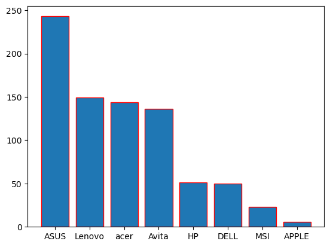

```python
plt.bar(df['brand'].unique(),df['brand'].value_counts(),edgecolor='r')
```

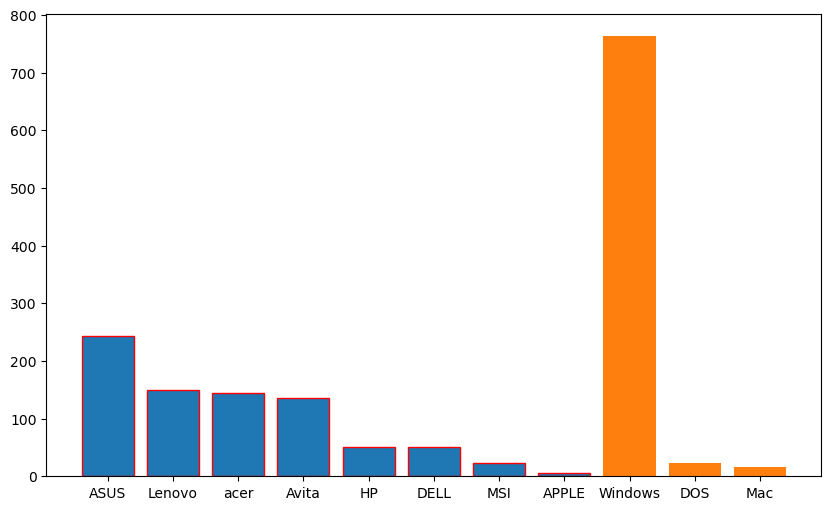

```python
plt.figure(figsize=(10,6))
plt.bar(df['brand'].unique(),df['brand'].value_counts(),edgecolor='r')
plt.bar(df['os'].unique(),df['os'].value_counts())
plt.show()
```

```python
print(cat)
```

```
['brand', 'processor_brand', 'processor_name', 'processor_gnrtn', 'ram_gb', 'ram_type', 'ssd', 'hdd', 'os', 'os_bit', 'graphic_card_gb', 'weight', 'warranty', 'Touchscreen', 'msoffice', 'rating']
```

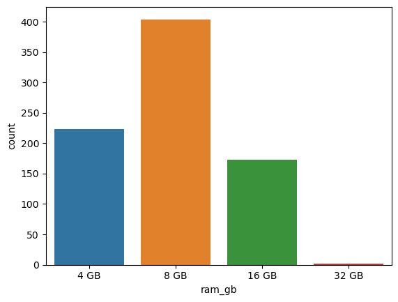

```python
sns.countplot(data=df,x=df['ram_gb'],hue=df['ram_gb'])
```

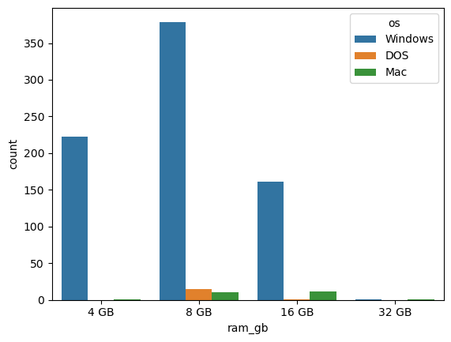

```python
sns.countplot(df,x=df['ram_gb'],hue='os')
```

```python
#df['ram']
```

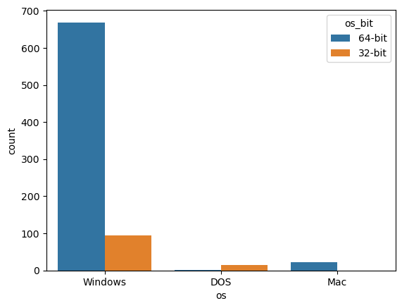

```python
sns.countplot(df,x=df['os'],hue='os_bit')
```

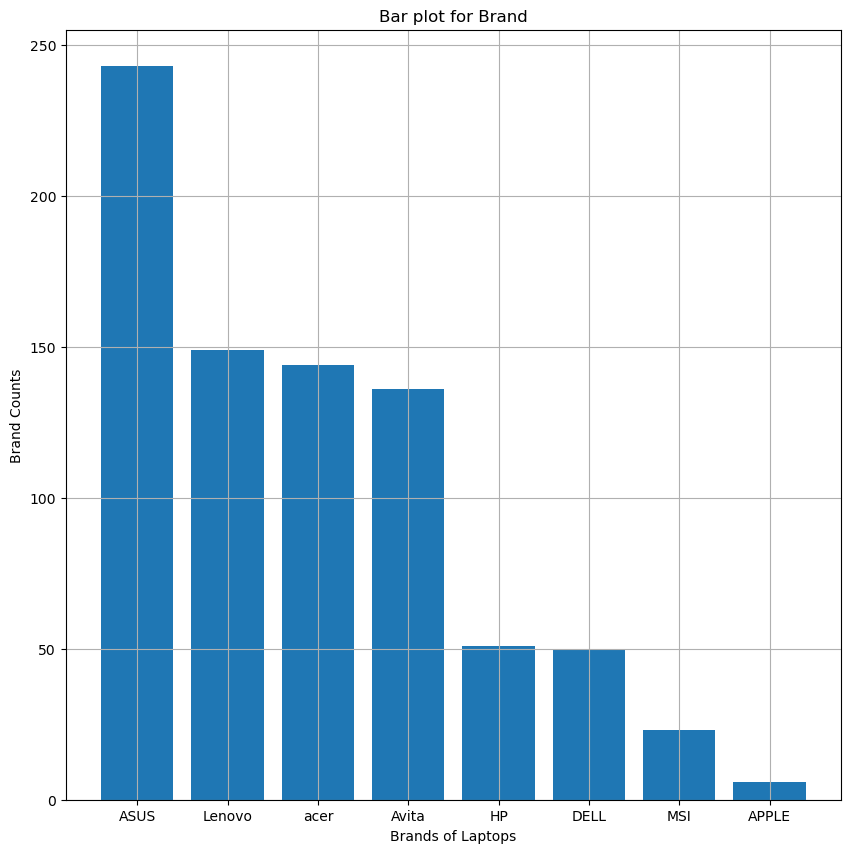

```python
plt.figure(figsize=(10,10))
plt.bar(df['brand'].unique(),df['brand'].value_counts())
plt.title("Bar plot for Brand")
plt.xlabel("Brands of Laptops")
plt.ylabel("Brand Counts")
plt.grid()
plt.show()
```

## Continuous feature

Histograms - Data Distribution

```python
con
```

```
['Price', 'Number of Ratings', 'Number of Reviews']
```

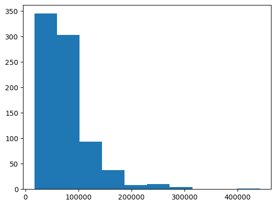

```python
plt.hist(df['Price'])
```

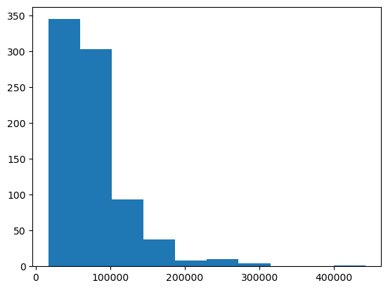

```python
plt.hist(df['Price'])
plt.show()
```

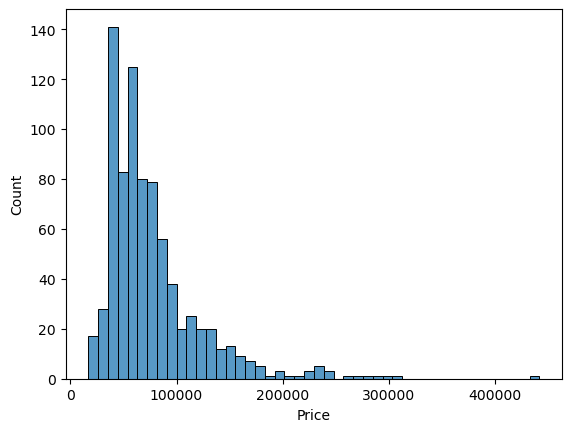

```python
sns.histplot(data=df,x='Price')
```

### KDE - Kernel Density Estimate

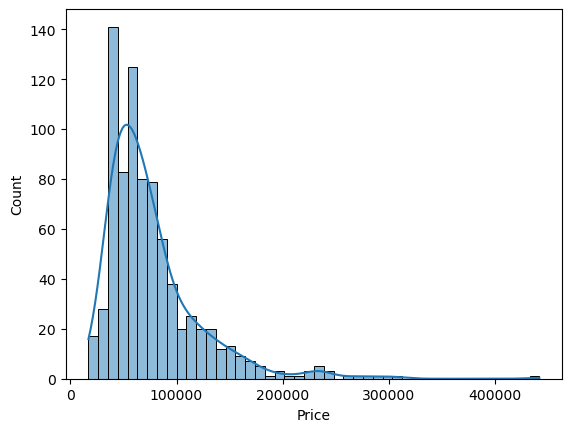

```python
sns.histplot(data=df,x='Price',kde=True)
```

### Above plot indicates that Price column contains skewed data

## Skewed data can be converted into normalised data using lognormal

## You can check whether the data is skewed or not using skew() method

dataframe[continuous column list].skew()

```
1. If the output is close to 0, data is symmertrical - normally distributed
2. If the output is greater than 1, data is positvely skewed
3. If the output is less than -1 , data is negativelty skewed
```

```python
df[con].skew()
```

```
Price                2.395163
Number of Ratings    7.914791
Number of Reviews    8.378608
dtype: float64
```

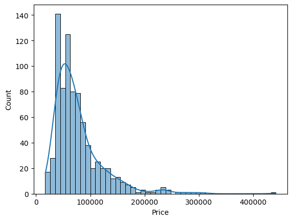

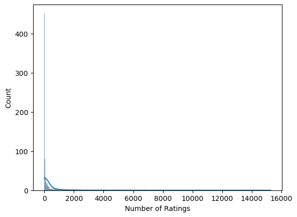

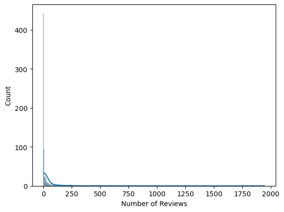

```python
for i in con:
    sns.histplot(data=df,x=i,kde=True)
    plt.show()
```

```python
df['Price'].min()
```

```
16990
```

```python
df['Price'].max()
```

```
441990
```

```python
## LOG TRANSFORMATION
import numpy as np
df['Price'] = np.log10(df['Price']+1) # log 0 to the base 10
df['Number of Ratings'] = np.log1p(df['Number of Ratings'])
df['Number of Reviews'] = np.log10(df['Number of Reviews']+1)
```

```python
df['Price'].min()
```

```
4.230218939887381
```

```python
df['Price'].max()
```

```
5.645413426158749
```

```python
df['Price']
```

```
0      4.539703
1      4.591065
2      4.602060
3      4.845042
4      4.431219
         ...
818    5.133510
819    5.161341
820    5.176065
821    5.155309
822    4.759600
Name: Price, Length: 802, dtype: float64
```

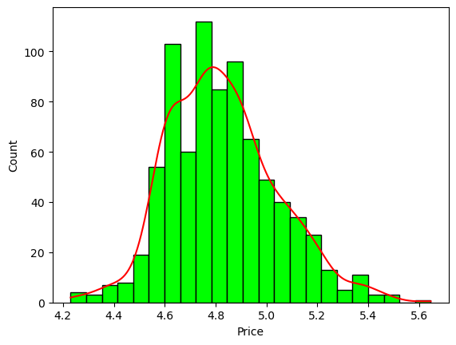

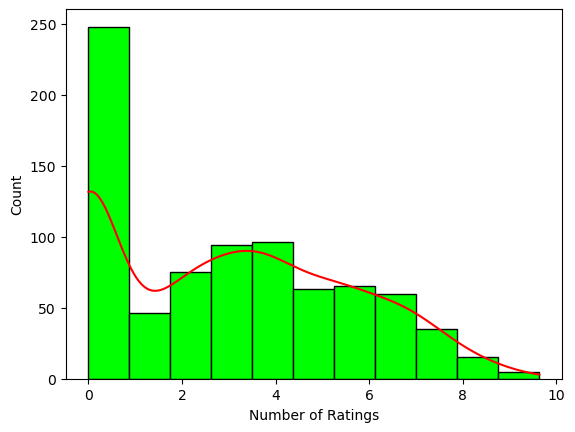

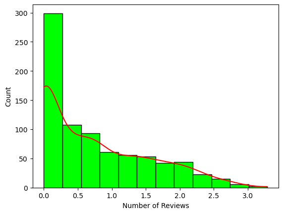

```python
for i in con:
    sns.histplot(df,x=i,kde=True,facecolor='lime',color='r')
    plt.show()
```

```python
df[con].skew()
```

```
Price                0.443566
Number of Ratings    0.320486
Number of Reviews    0.852159
dtype: float64
```

## Types:

```
Continuous vs continuous
Categorical vs Categorical
Categorical vs Continuous
```

```python
df.columns
```

```
Index(['brand', 'processor_brand', 'processor_name', 'processor_gnrtn',
       'ram_gb', 'ram_type', 'ssd', 'hdd', 'os', 'os_bit', 'graphic_card_gb',
       'weight', 'warranty', 'Touchscreen', 'msoffice', 'Price', 'rating',
       'Number of Ratings', 'Number of Reviews'],
      dtype='object')
```

## Continuous vs Continuous features

```
Scatter plot
Heatmaps
```

Correlation :

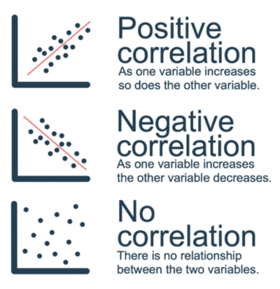

```python
con
```

```
['Price', 'Number of Ratings', 'Number of Reviews']
```

```python
import seaborn as sns
```

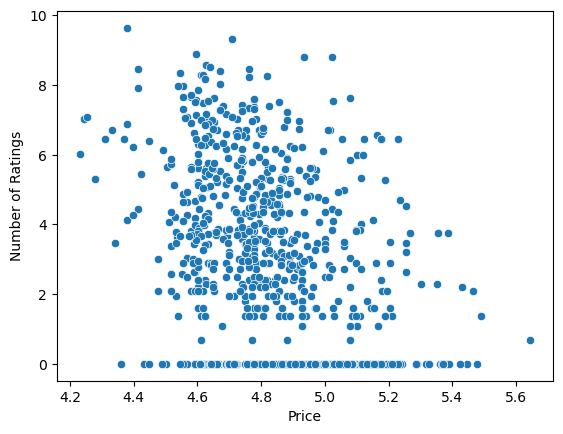

```python
sns.scatterplot(data=df,x='Price',y='Number of Ratings')
plt.show()
```

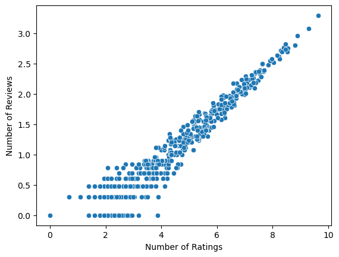

```python
sns.scatterplot(data=df,x='Number of Ratings',y='Number of Reviews')
plt.show()
```

## There is a positive relationship between Number of Ratings and Number of Reviews

## If the ratings increase, then reviews automatically increase

```python
# TO check for the correlation score
df[con].corr()
```

|  | Price | Number of Ratings | Number of Reviews |
| --- | --- | --- | --- |
| Price | 1.000000 | -0.357209 | -0.313774 |
| Number of Ratings | -0.357209 | 1.000000 | 0.958253 |
| Number of Reviews | -0.313774 | 0.958253 | 1.000000 |

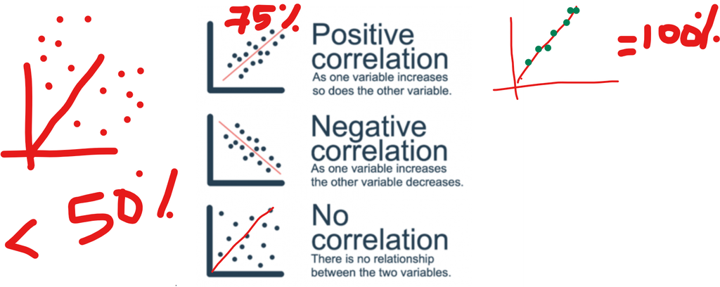

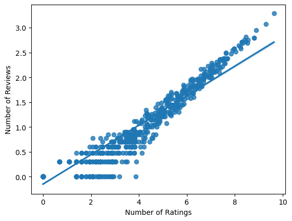

```python
sns.regplot(data=df,x='Number of Ratings',y='Number of Reviews')
plt.show()
```

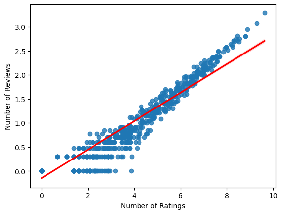

```python
sns.regplot(data=df,x='Number of Ratings',y='Number of Reviews',line_kws={"color":"red"})
plt.show()
```

## Heatmaps

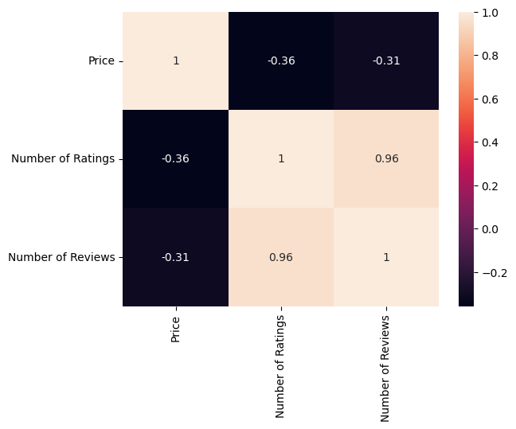

```python
df_cor = df[con].corr()
sns.heatmap(data=df_cor,annot=True)
plt.show()
```

## Categorical vs Continuous

Box plots

```python
print(cat)
```

```
['brand', 'processor_brand', 'processor_name', 'processor_gnrtn', 'ram_gb', 'ram_type', 'ssd', 'hdd', 'os', 'os_bit', 'graphic_card_gb', 'weight', 'warranty', 'Touchscreen', 'msoffice', 'rating']
```

```python
print(con)
```

```
['Price', 'Number of Ratings', 'Number of Reviews']
```

```python
df1 = pd.read_csv(r"E:\Sindhura\DataSets\laptopPrice.csv")
df1.head(2)
```

|  | brand | processor_brand | processor_name | processor_gnrtn | ram_gb | ram_type | ssd | hdd | os | os_bit | graphic_card_gb | weight | warranty | Touchscreen | msoffice | Price | rating | Number of Ratings | Number of Reviews |
| --- | --- | --- | --- | --- | --- | --- | --- | --- | --- | --- | --- | --- | --- | --- | --- | --- | --- | --- | --- |
| 0 | ASUS | Intel | Core i3 | 10th | 4 GB | DDR4 | 0 GB | 1024 GB | Windows | 64-bit | 0 GB | Casual | No warranty | No | No | 34649 | 2 stars | 3 | 0 |
| 1 | Lenovo | Intel | Core i3 | 10th | 4 GB | DDR4 | 0 GB | 1024 GB | Windows | 64-bit | 0 GB | Casual | No warranty | No | No | 38999 | 3 stars | 65 | 5 |

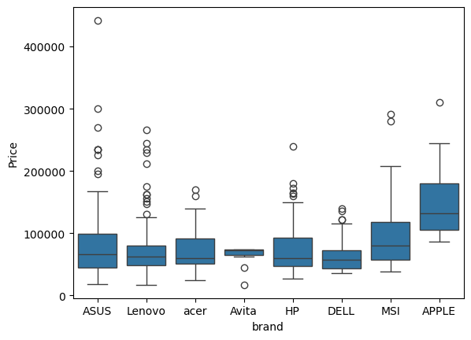

```python
sns.boxplot(data=df1,x='brand',y='Price')
plt.show()
```